# Brand preference

David Gibert Bosque

October 2018

# **REPORT DESCRIPTION**

This report main objective is to predict the customer’s brand preference on laptops (Sony or Acer) based on their characteristics such as Age and Salary.

# **SUMMARISED REPORT**

### 1. Metrics about the models used on classification

[output not shown]

### 2. Predicting brand

Image showing the predicted amount of values for each brand on the incompete dataset

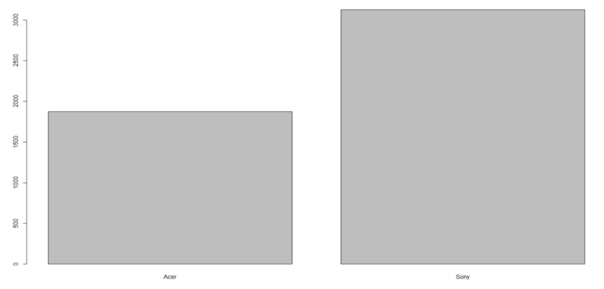

### 3. Data distribution

Image that shows the distribution of customers by Age.

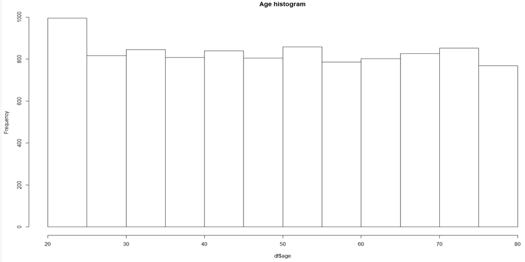

### 4. Salary distribution comparison

Image showing distributions for Salary and Brand for both, Predicted and Original dataset. The distribution of data is quite similar, so we can use the model to predict on this data.

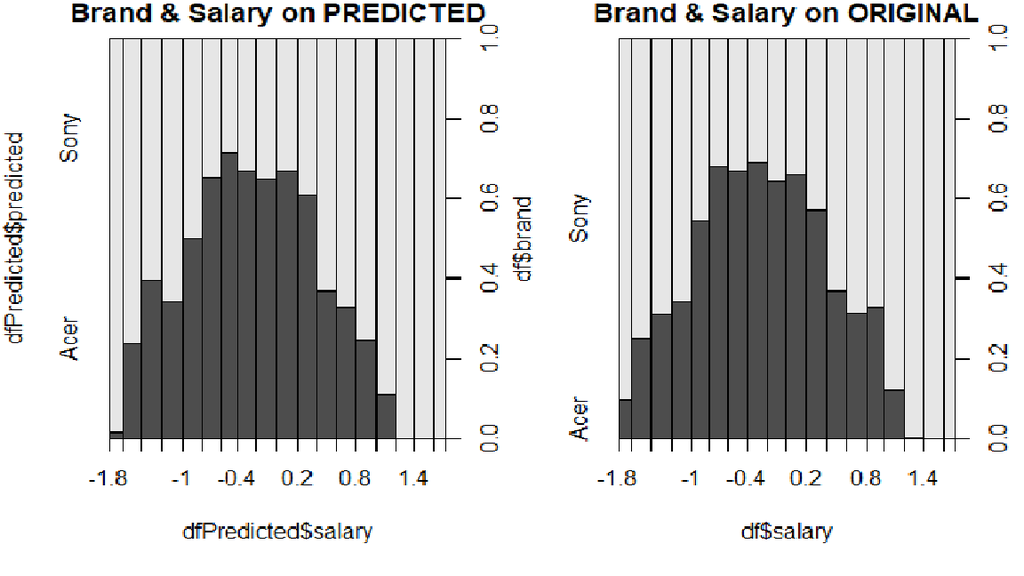

The distributions among data attributes on the Predicted values are quite similar compared to the distributions on the Original data set, which means we can use the model to classify customers that have this very similar characteristics to ones on our dataset. Due to to the issue that the sampling of customers has not been random, we cannot extrapolate the info for any new potential customer. Then again, is very important to make clear that the model for classification works, but only for potential customers that have similar attribute characteristics to the ones used for training our model, not for any kind of customer.

**To improve this model and make it useful to classify any new potential customer, we would need access to a new sample, as big as possible, of randomly selected customers.**

# **Loading data set**

```r
# df = read.xlsx(file = "C:/Users/David/Google Drive/Ubiqum/3_BrandPreference/survey_complete.xlsx",
#                sheetIndex = 2)
# save(df, file = "survey_complete.Rdata")
load("survey_complete.Rdata")
head(df)
```

|  | salary | age | elevel | car | zipcode | credit | brand |
| --- | --- | --- | --- | --- | --- | --- | --- |
| 1 | 119806.54 | 45 | 0 | 14 | 4 | 442037.71 | 0 |
| 2 | 106880.48 | 63 | 1 | 11 | 6 | 45007.18 | 1 |
| 3 | 78020.75 | 23 | 0 | 15 | 2 | 48795.32 | 0 |
| 4 | 63689.94 | 51 | 3 | 6 | 5 | 40888.88 | 1 |
| 5 | 50873.62 | 20 | 3 | 14 | 4 | 352951.50 | 0 |
| 6 | 130812.74 | 56 | 3 | 14 | 3 | 135943.02 | 1 |

# **Checking structure**

```r
str(df)
```

```
## 'data.frame':    10000 obs. of  7 variables:
##  $ salary : num  119807 106880 78021 63690 50874 ...
##  $ age    : num  45 63 23 51 20 56 24 62 29 41 ...
##  $ elevel : num  0 1 0 3 3 3 4 3 4 1 ...
##  $ car    : num  14 11 15 6 14 14 8 3 17 5 ...
##  $ zipcode: num  4 6 2 5 4 3 5 0 0 4 ...
##  $ credit : num  442038 45007 48795 40889 352951 ...
##  $ brand  : num  0 1 0 1 0 1 1 1 0 1 ...
```

*We need to format the label attributes properly, as all attributes appear like numeric and that is not the way all data is.*

# **Formatting data properly**

```r
df$elevel = factor(x = df$elevel,
                   levels = 0:4,
                   labels = c("Less_Than_High_School", "High_School", "Some_College", "4_Year_Degree_College", "Master_PHD"),
                   ordered = TRUE) #Making 'elevel' an ordinal factor attribute

df$zipcode = factor(x = df$zipcode,
                    levels = 0:8,labels = c("New_England", "Mid_Atlantic", "ENC", "WNC", "South_Atlantic", "ESC", "WSC", "Mountain", "Pacific"),
                    ordered = FALSE) #Labeling regions

df$brand = factor(x = df$brand,
                  levels = 0:1,
                  labels = c("Acer", "Sony"),
                  ordered = FALSE) #Labeling factors

df$car = as.factor(df$car) #Convert variable to factor

str(df)
```

```
## 'data.frame':    10000 obs. of  7 variables:
##  $ salary : num  119807 106880 78021 63690 50874 ...
##  $ age    : num  45 63 23 51 20 56 24 62 29 41 ...
##  $ elevel : Ord.factor w/ 5 levels "Less_Than_High_School"<..: 1 2 1 4 4 4 5 4 5 2 ...
##  $ car    : Factor w/ 20 levels "1","2","3","4",..: 14 11 15 6 14 14 8 3 17 5 ...
##  $ zipcode: Factor w/ 9 levels "New_England",..: 5 7 3 6 5 4 6 1 1 5 ...
##  $ credit : num  442038 45007 48795 40889 352951 ...
##  $ brand  : Factor w/ 2 levels "Acer","Sony": 1 2 1 2 1 2 2 2 1 2 ...
```

# **Feature engineering - Rows with value 0 at “Credit”**

```r
# df = df[!df$credit == 0, ] #Deletig rows were the "credit" value is 0
# df["new"] <- df$salary/df$credit
# cor(df[,c("salary", "credit", "new")])
```

# **Exploring data distribution**

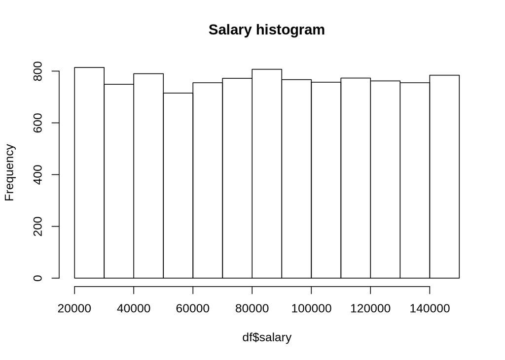

```r
hist(df$salary, main = "Salary histogram")
```

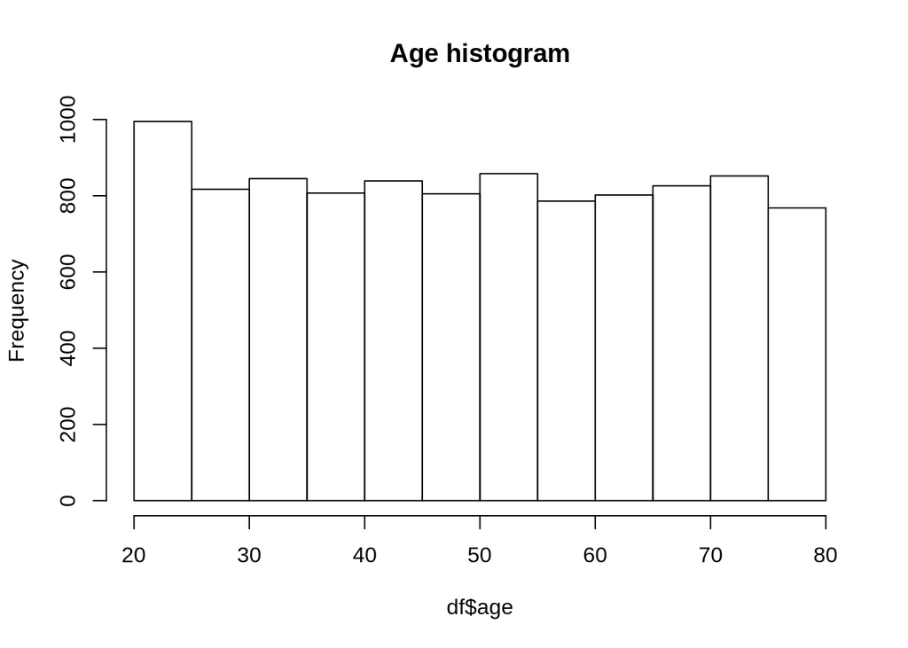

```r
hist(df$age, main = "Age histogram")
```

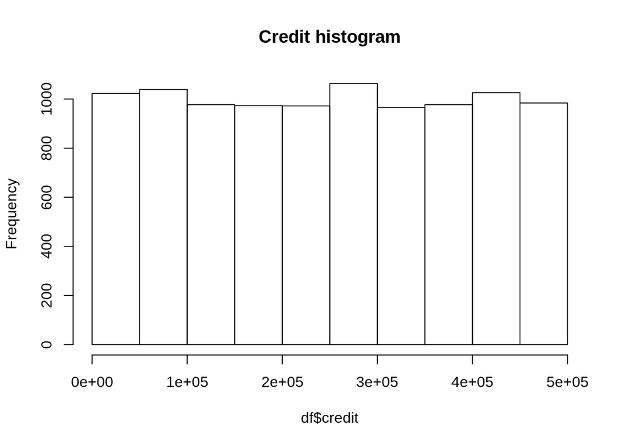

```r
hist(df$credit, main = "Credit histogram")
```

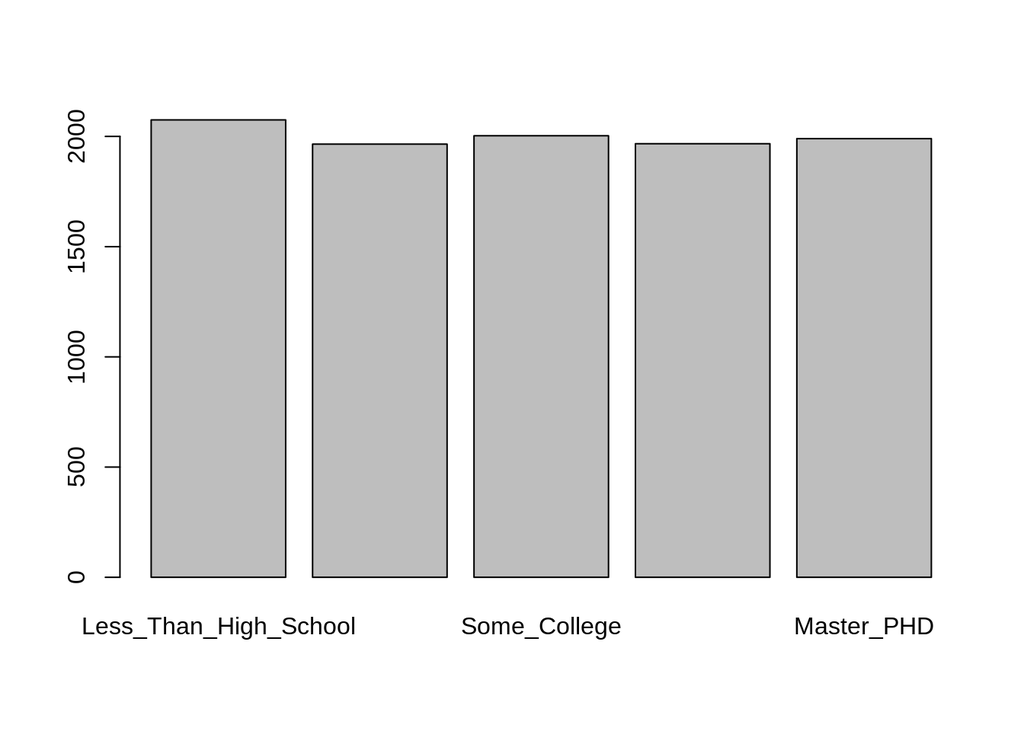

```r
barplot(table(df$elevel))
```

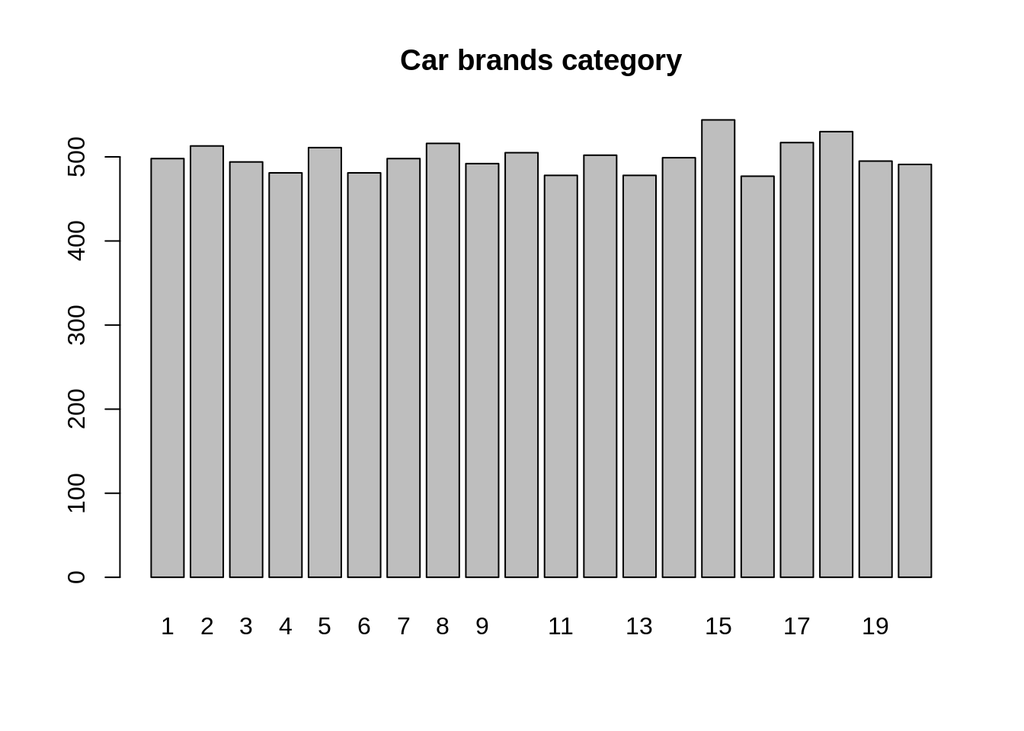

```r
barplot(table(df$car), main = "Car brands category")
```

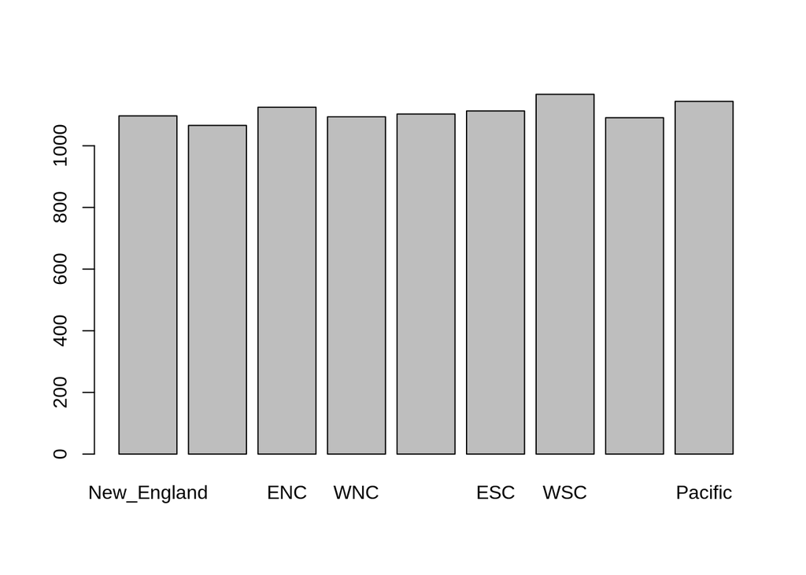

```r
barplot(table(df$zipcode))
```

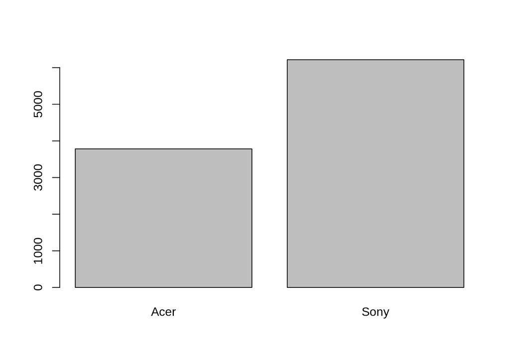

```r
barplot(table(df$brand))
```

```r
table(df$zipcode)
```

```
##
##    New_England   Mid_Atlantic            ENC            WNC South_Atlantic
##           1097           1066           1125           1094           1103
##            ESC            WSC       Mountain        Pacific
##           1113           1167           1091           1144
```

*We can see that all the attributes follow some kind of uniform distribution, which is a little bit awkward.* *Almost the same amount of people has been selected in this study in each region. The sampling method does not look random at all.*

# **Correlation plot**

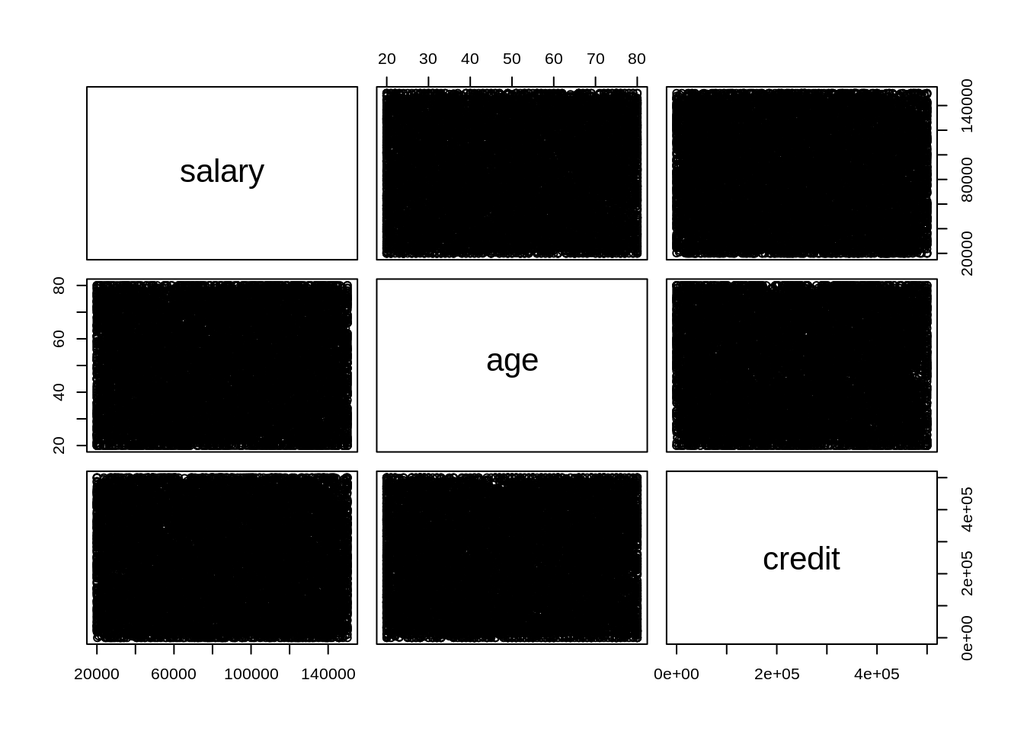

```r
df2 = df[c("salary", "age", "credit")]
plot(df2)
```

```r
cor(df2)
```

```
##              salary          age       credit
## salary  1.000000000  0.007025207 -0.024047739
## age     0.007025207  1.000000000 -0.004960033
## credit -0.024047739 -0.004960033  1.000000000
```

*As we can see beforehand, there isn’t any kind of correlation between the numeric attributes.*

# **Relation between attributes and Dependent variable “Brand”**

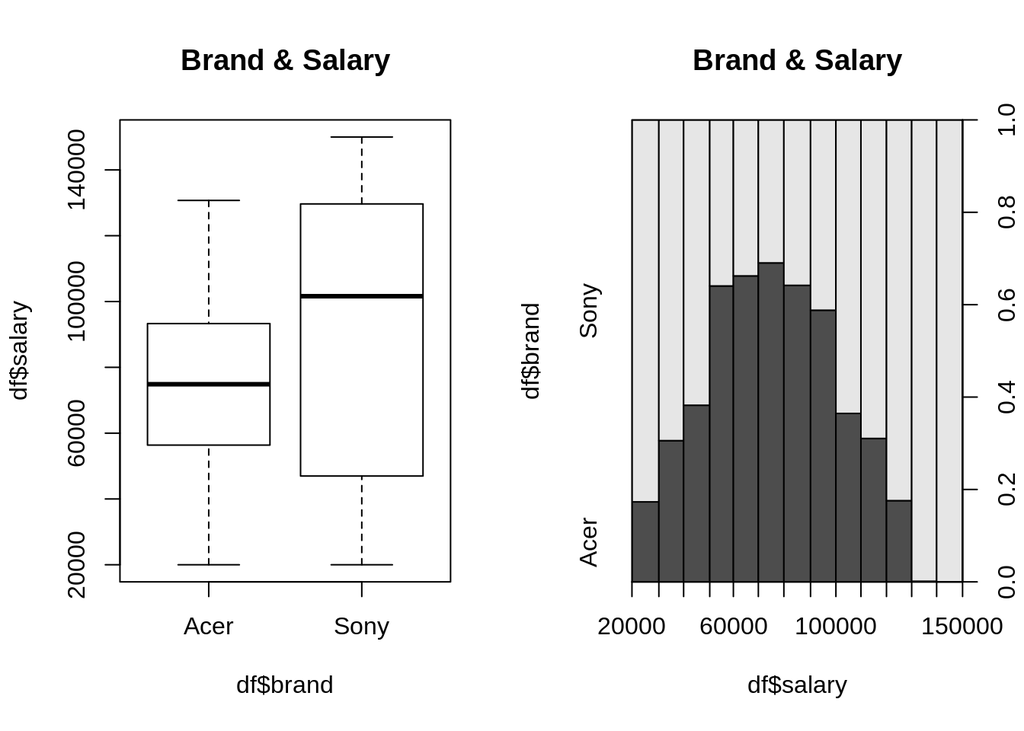

```r
par(mfrow = c(1,2))
plot(df$salary~df$brand, main = "Brand & Salary")
plot(df$brand~df$salary, main = "Brand & Salary")
```

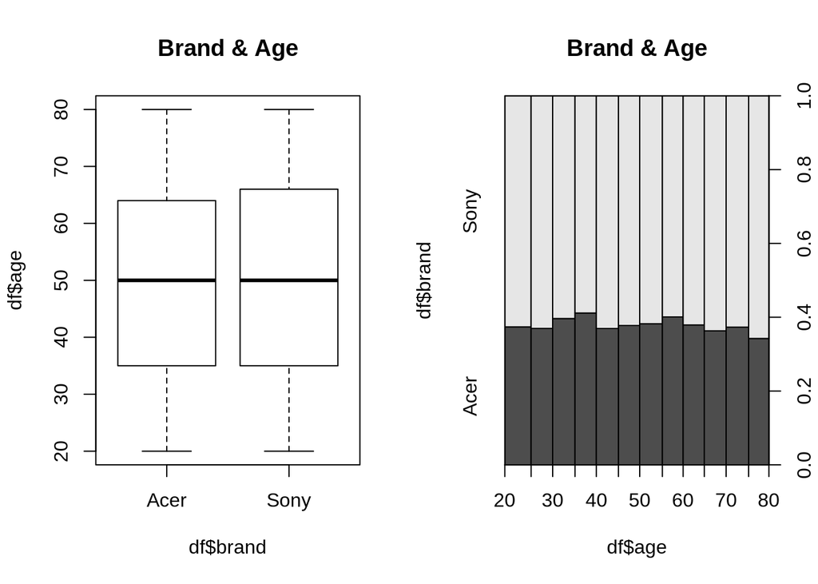

```r
par(mfrow = c(1,2))
plot(df$age~df$brand, main = "Brand & Age")
plot(df$brand~df$age, main = "Brand & Age")
```

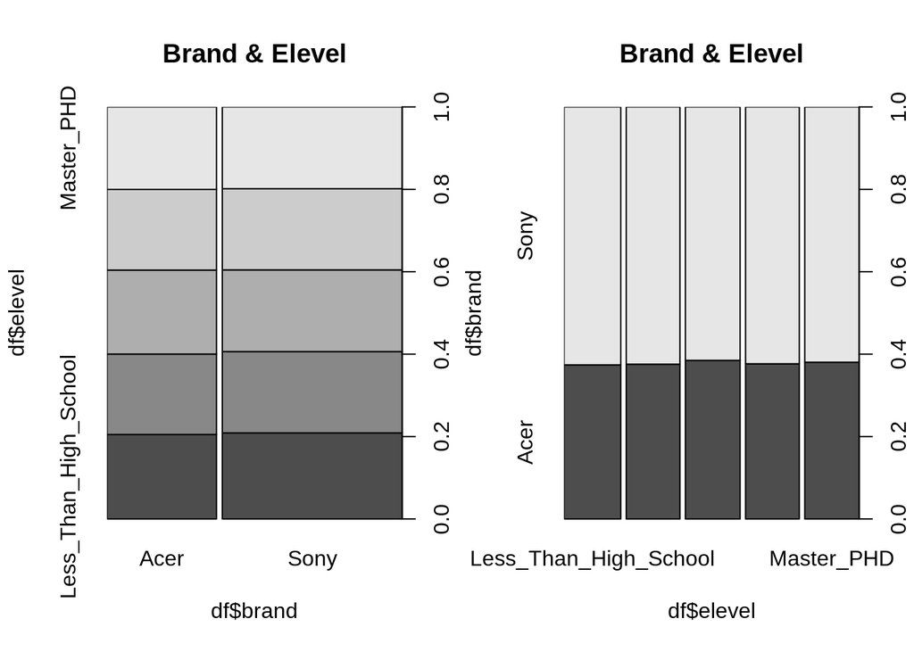

```r
par(mfrow = c(1,2))
plot(df$elevel~df$brand, main = "Brand & Elevel")
plot(df$brand~df$elevel, main = "Brand & Elevel")
```

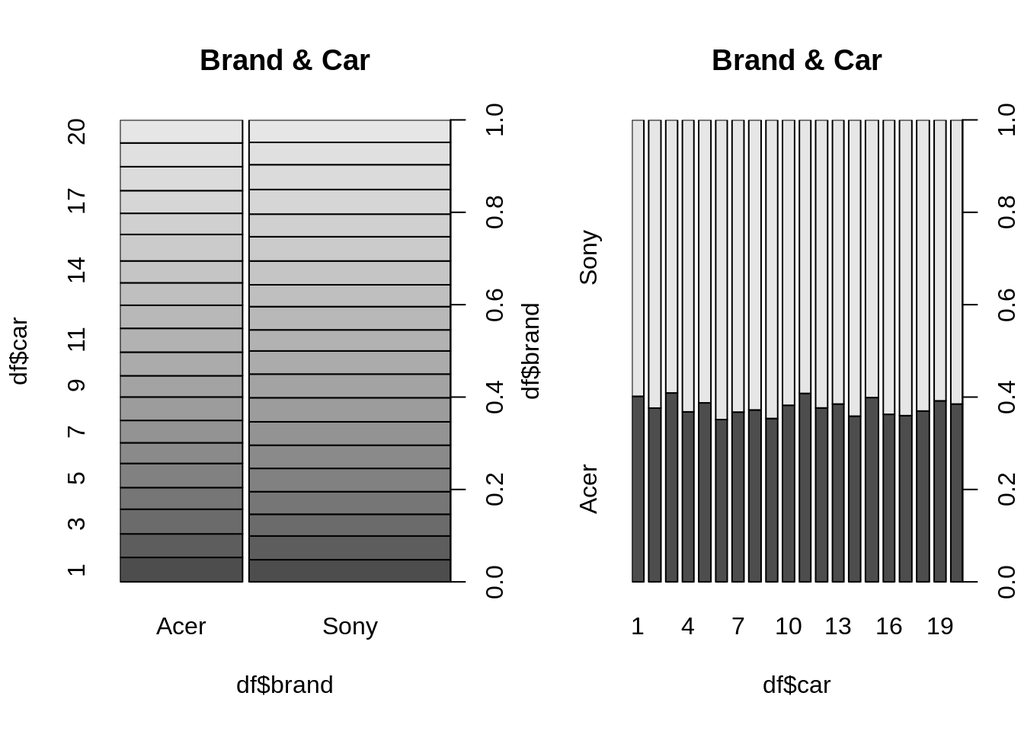

```r
par(mfrow = c(1,2))
plot(df$car~df$brand, main = "Brand & Car")
plot(df$brand~df$car, main = "Brand & Car")
```

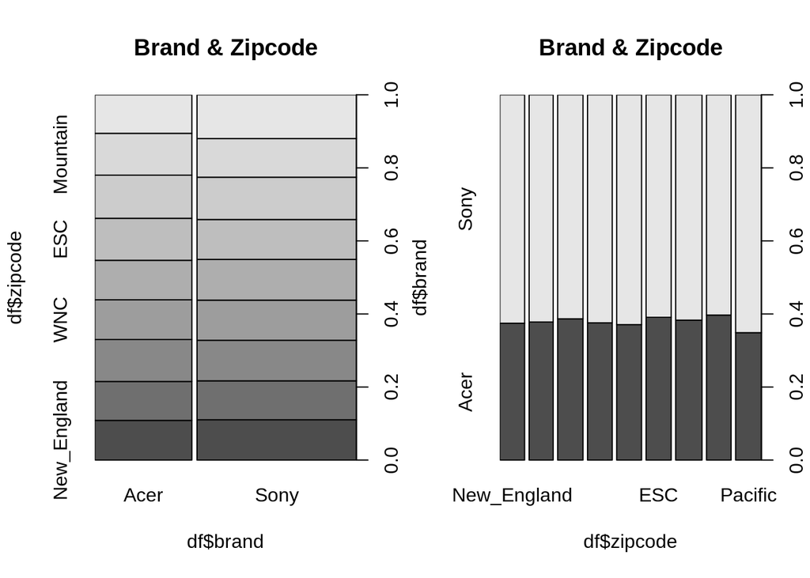

```r
par(mfrow = c(1,2))
plot(df$zipcode~df$brand, main = "Brand & Zipcode")
plot(df$brand~df$zipcode, main = "Brand & Zipcode")
```

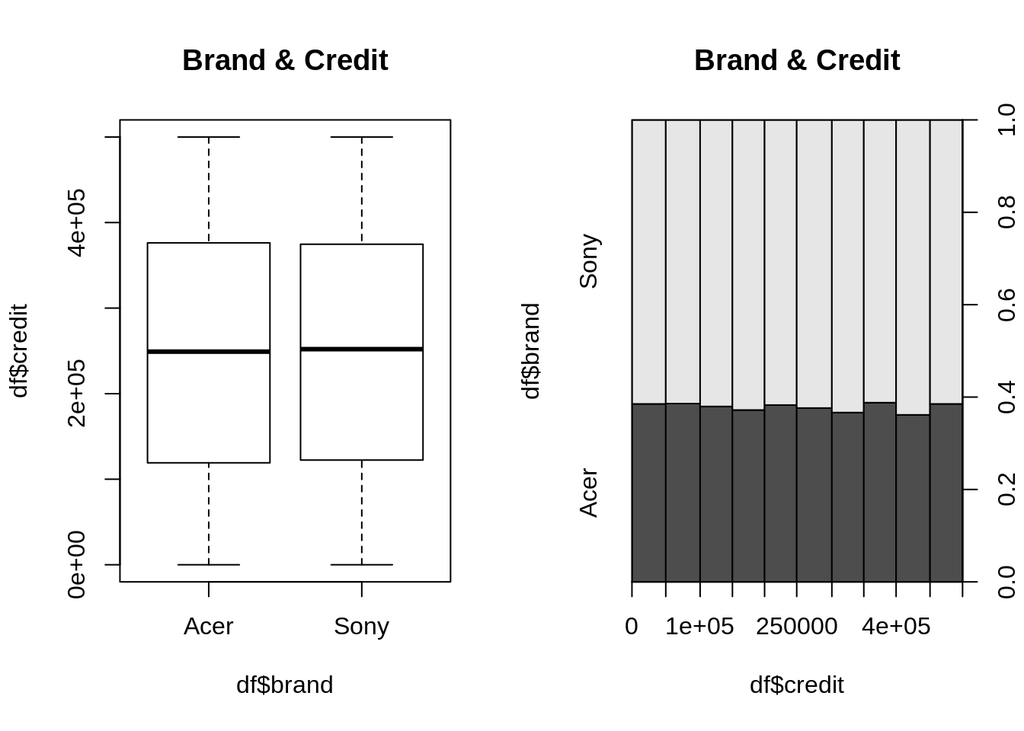

```r
par(mfrow = c(1,2))
plot(df$credit~df$brand, main = "Brand & Credit")
plot(df$brand~df$credit, main = "Brand & Credit")
```

# **Looking at a Decision Tree variables importance**

```r
tree = rpart(formula = brand~., data = df)
sumtree = summary(tree, file = "summTree")
sumtree$variable.importance
```

```
##        age     salary        car    zipcode     credit     elevel
## 2036.06398 1421.30552   78.59978   42.70644   21.20404   16.06770
```

*The tree shows that the most important variables to segment customers are Age and Salary.*

# **Age & Salary vs Brand individually and gathered**

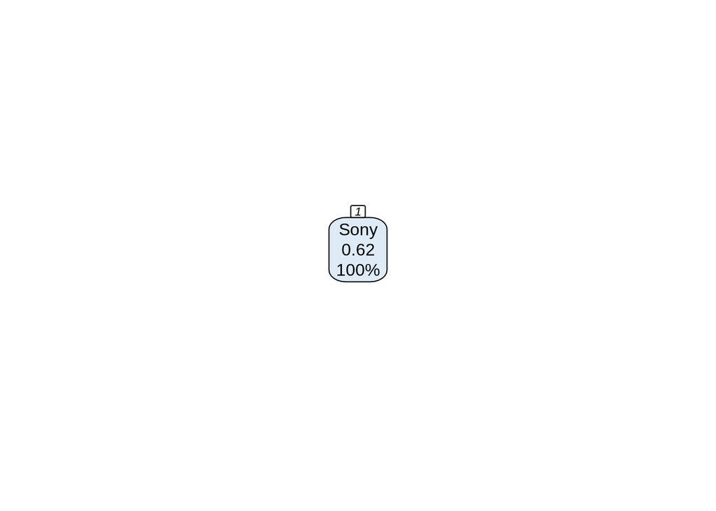

```r
treeAge = rpart(formula = brand~age, data = df)
rpart.plot(x = treeAge, box.palette = "RdBu", nn = TRUE)
```

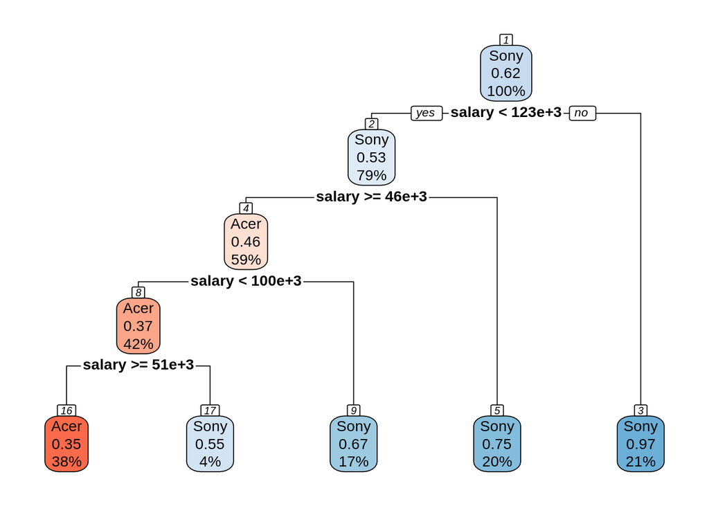

```r
treeSalary = rpart(formula = brand~salary, data = df)
rpart.plot(x = treeSalary, box.palette = "RdBu", nn = TRUE)
```

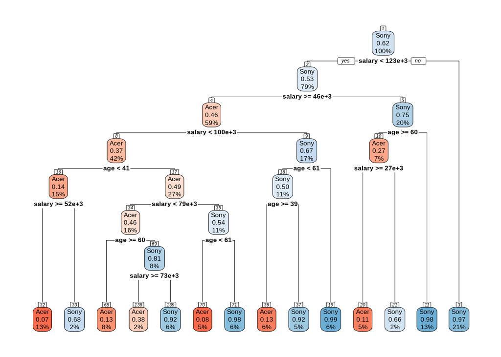

```r
tree = rpart(formula = brand~age+salary, data = df)
rpart.plot(x = tree, box.palette = "RdBu", nn = TRUE)
```

*1. We can see how ‘Age’ alone does not explain anything about the chosen brand.*

*2. Salary itself segments customers pretty fine.*

*3. We must gather ‘Salary’ and ‘Age’ because they both explain better the segmentation of customers.*

# **Normalizing data**

```r
df$salary <- (df$salary - mean(df$salary)) / sd(df$salary)
df$age <- (df$age - mean(df$age)) / sd(df$age)
df$credit <- (df$credit - mean(df$credit)) / sd(df$credit)
head(df)
```

|  | salary | age | elevel | car | zipcode | credit | brand |
| --- | --- | --- | --- | --- | --- | --- | --- |
| 1 | 0.9257352 | -0.27343783 | Less_Than_High_School | 14 | South_Atlantic | 1.3278137 | Acer |
| 2 | 0.5829578 | 0.74950324 | High_School | 11 | WSC | -1.4066346 | Sony |
| 3 | -0.1823531 | -1.52369914 | Less_Than_High_School | 15 | ENC | -1.3805447 | Acer |
| 4 | -0.5623819 | 0.06754253 | 4_Year_Degree_College | 6 | ESC | -1.4349983 | Sony |
| 5 | -0.9022489 | -1.69418932 | 4_Year_Degree_College | 14 | South_Atlantic | 0.7142548 | Acer |
| 6 | 1.2176008 | 0.35169282 | 4_Year_Degree_College | 14 | WNC | -0.7803367 | Sony |

*Normalizing transforms all attributes values so they have the same range on a Z distribution.*

# **Train & Test data.frames**

```r
idxs = createDataPartition(y = df$brand, list = FALSE, p = 0.75)
train = df[idxs, ]
test = df[-idxs, ]
```

# **Checking distribution in original and partitioned data**

```r
prop.table(table(train$brand)) * 100 #Training set
```

```
##
##     Acer     Sony
## 37.83496 62.16504
```

```r
prop.table(table(test$brand)) * 100 #Test set
```

```
##
##     Acer     Sony
## 37.81513 62.18487
```

```r
prop.table(table(df$brand)) * 100 #Original set
```

```
##
##  Acer  Sony
## 37.83 62.17
```

*We can see how the function “createDataPartition” distributes data proportionally equal between partitions (not just randomly).*

# **KNN model**

```r
ctrl <- trainControl(method = "repeatedcv", number = 10, repeats = 3)

knnFit <- train(brand ~ age+salary,
                data = train,
                method = "knn",
                trControl = ctrl,
                tuneLength = 10)

#Output of kNN fit
knnFit
```

```
## k-Nearest Neighbors
##
## 7501 samples
##    2 predictor
##    2 classes: 'Acer', 'Sony'
##
## No pre-processing
## Resampling: Cross-Validated (10 fold, repeated 3 times)
## Summary of sample sizes: 6751, 6750, 6750, 6751, 6751, 6751, ...
## Resampling results across tuning parameters:
##
##   k   Accuracy   Kappa
##    5  0.9148567  0.8192847
##    7  0.9167659  0.8232451
##    9  0.9171661  0.8242526
##   11  0.9197873  0.8298231
##   13  0.9203207  0.8309649
##   15  0.9214763  0.8333910
##   17  0.9209878  0.8322868
##   19  0.9205433  0.8313862
##   21  0.9203651  0.8309584
##   23  0.9208989  0.8320532
##
## Accuracy was used to select the optimal model using the largest value.
## The final value used for the model was k = 15.
```

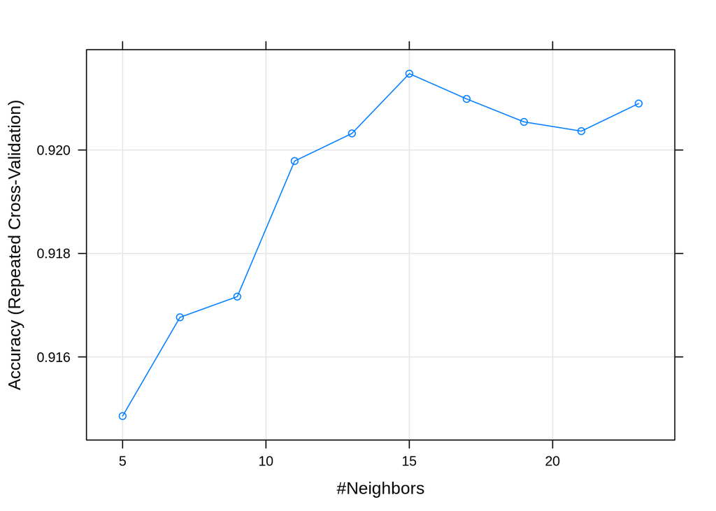

```r
plot(knnFit)
```

# **KNN with k = 5**

```r
knnFit <- train(brand ~ age+salary,
                data = train,
                method = "knn",
                trControl = ctrl,
                tuneGrid = expand.grid(k = 5))

knnFit
```

```
## k-Nearest Neighbors
##
## 7501 samples
##    2 predictor
##    2 classes: 'Acer', 'Sony'
##
## No pre-processing
## Resampling: Cross-Validated (10 fold, repeated 3 times)
## Summary of sample sizes: 6751, 6751, 6751, 6751, 6750, 6751, ...
## Resampling results:
##
##   Accuracy   Kappa
##   0.9164978  0.8226725
##
## Tuning parameter 'k' was held constant at a value of 5
```

# **KNN performance**

```r
knnPredict <- predict(knnFit, newdata = test)
#Get the confusion matrix to see accuracy value and other parameter values

confmat = confusionMatrix(knnPredict, test$brand)
knitr::kable(confmat$table)
```

|  | Acer | Sony |
| --- | --- | --- |
| Acer | 846 | 115 |
| Sony | 99 | 1439 |

```r
knnMet = postResample(pred = knnPredict, test$brand)
knnMet
```

```
##  Accuracy     Kappa
## 0.9143657 0.8185200
```

*Looks like our model works pretty well on the test-split data, but we need to take a look at how it performs on our validation data. Before that, let’s define a Random Forest model to see if it improves the error rates of KNN on the test data.*

# **Random Forest model**

```r
rfFit = randomForest(brand ~ age+salary, data = train, ntree = 60)

#Output of random forest fit
rfFit
```

```
##
## Call:
##  randomForest(formula = brand ~ age + salary, data = train, ntree = 60)
##                Type of random forest: classification
##                      Number of trees: 60
## No. of variables tried at each split: 1
##
##         OOB estimate of  error rate: 8.55%
## Confusion matrix:
##      Acer Sony class.error
## Acer 2549  289  0.10183228
## Sony  352 4311  0.07548788
```

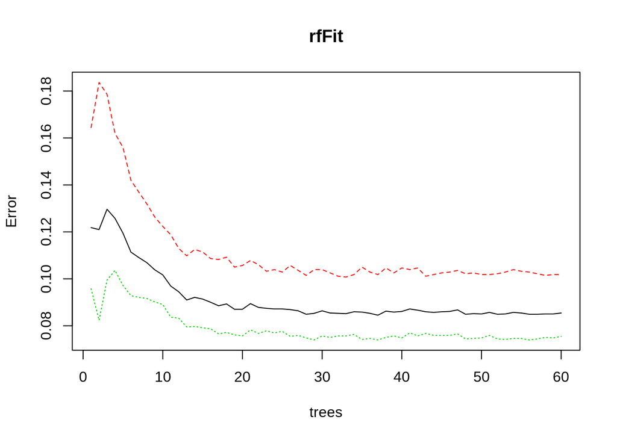

```r
plot(rfFit)
```

*The optimal number of trees is between 20 and 30.*

# **RF performance**

```r
rfPredict <- predict(rfFit, newdata = test)
confmat = confusionMatrix(rfPredict, test$brand)
knitr::kable(confmat$table)
```

|  | Acer | Sony |
| --- | --- | --- |
| Acer | 846 | 120 |
| Sony | 99 | 1434 |

```r
rfMet = postResample(pred = rfPredict, test$brand)
rfMet
```

```
##  Accuracy     Kappa
## 0.9123649 0.8144715
```

*Looks like Random Forest performs great, just as KNN.*

# **Metrics for predicted data on the test set**

```r
metrics = matrix(c(knnMet[1], knnMet[2], rfMet[1], rfMet[2]),
                 ncol = 2,
                 nrow = 2,
                 byrow = T)
colnames(metrics) <- c("KNN k = 5", "Random Forest")
rownames(metrics) <- c("Accuracy", "Kappa")
metrics = knitr::kable(metrics)
# save(... = metrics, file = "metrics.Rdata")
metrics
```

[output not shown]

# **Loading incomplete data**

```r
# dfIncomp = read.csv(file = "C:/Users/David/Google Drive/Ubiqum/3_BrandPreference/survey_incomplete.csv")
# save(dfIncomp, file = "survey_incomplete.Rdata")
load("survey_incomplete.Rdata")
head(dfIncomp)
```

|  | salary | age | elevel | car | zipcode | credit | brand |
| --- | --- | --- | --- | --- | --- | --- | --- |
| 1 | 110499.74 | 54 | 3 | 15 | 4 | 354724.18 | 0 |
| 2 | 140893.78 | 44 | 4 | 20 | 7 | 395015.34 | 0 |
| 3 | 119159.65 | 49 | 2 | 1 | 3 | 122025.09 | 0 |
| 4 | 20000.00 | 56 | 0 | 9 | 1 | 99629.62 | 0 |
| 5 | 93956.32 | 59 | 1 | 15 | 1 | 458679.83 | 0 |
| 6 | 41365.43 | 71 | 2 | 7 | 2 | 216839.72 | 0 |

```r
str(dfIncomp)
```

```
## 'data.frame':    5000 obs. of  7 variables:
##  $ salary : num  110500 140894 119160 20000 93956 ...
##  $ age    : int  54 44 49 56 59 71 32 33 32 58 ...
##  $ elevel : int  3 4 2 0 1 2 1 4 1 2 ...
##  $ car    : int  15 20 1 9 15 7 17 17 19 8 ...
##  $ zipcode: int  4 7 3 1 1 2 1 0 2 4 ...
##  $ credit : num  354724 395015 122025 99630 458680 ...
##  $ brand  : int  0 0 0 0 0 0 0 0 0 0 ...
```

# **Format new data frame**

```r
dfIncomp$elevel = factor(x = dfIncomp$elevel,
                   levels = 0:4,
                   labels = c("Less_Than_High_School", "High_School", "Some_College", "4_Year_Degree_College", "Master_PHD"),
                   ordered = TRUE) #Making 'elevel' an ordinal factor attribute

dfIncomp$zipcode = factor(x = dfIncomp$zipcode,
                    levels = 0:8,labels = c("New_England", "Mid_Atlantic", "ENC", "WNC", "South_Atlantic", "ESC", "WSC", "Mountain", "Pacific"),
                    ordered = FALSE) #Labeling regions

dfIncomp$brand = factor(x = dfIncomp$brand,
                  levels = 0:1,
                  labels = c("Acer", "Sony"),
                  ordered = FALSE) #Labeling factors

dfIncomp$car = as.factor(dfIncomp$car) #Convert variable to factor

str(dfIncomp)
```

```
## 'data.frame':    5000 obs. of  7 variables:
##  $ salary : num  110500 140894 119160 20000 93956 ...
##  $ age    : int  54 44 49 56 59 71 32 33 32 58 ...
##  $ elevel : Ord.factor w/ 5 levels "Less_Than_High_School"<..: 4 5 3 1 2 3 2 5 2 3 ...
##  $ car    : Factor w/ 20 levels "1","2","3","4",..: 15 20 1 9 15 7 17 17 19 8 ...
##  $ zipcode: Factor w/ 9 levels "New_England",..: 5 8 4 2 2 3 2 1 3 5 ...
##  $ credit : num  354724 395015 122025 99630 458680 ...
##  $ brand  : Factor w/ 2 levels "Acer","Sony": 1 1 1 1 1 1 1 1 1 1 ...
```

# **Exploring data distribution for the Incomplete Dataset**

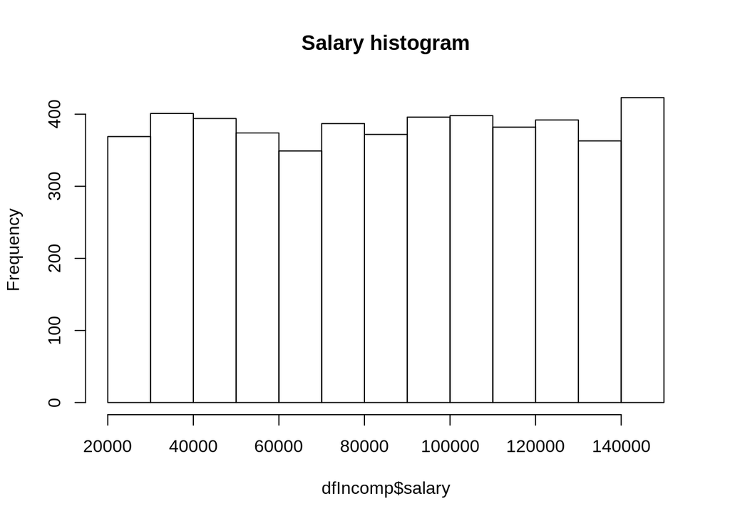

```r
hist(dfIncomp$salary, main = "Salary histogram")
```

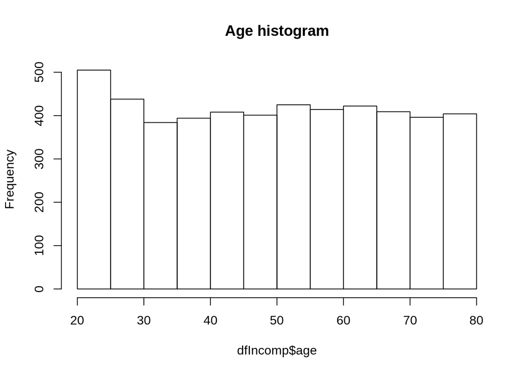

```r
hist(dfIncomp$age, main = "Age histogram")
```

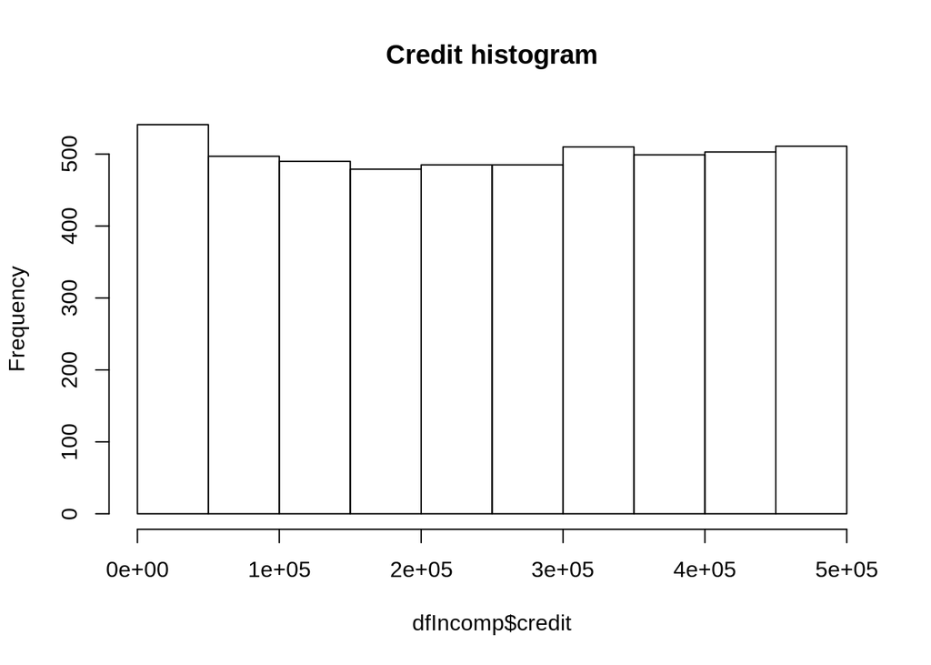

```r
hist(dfIncomp$credit, main = "Credit histogram")
```

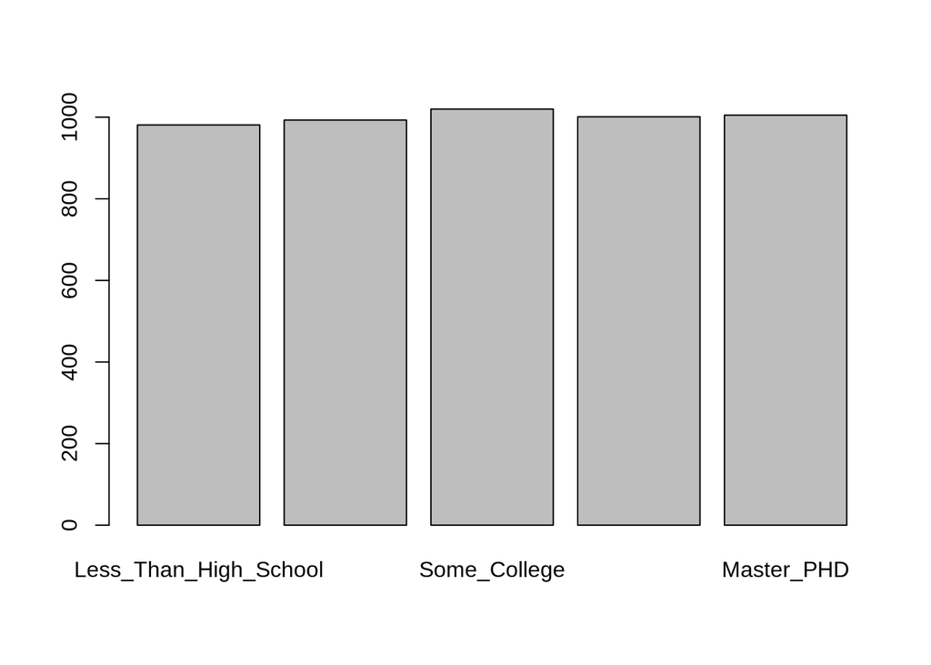

```r
barplot(table(dfIncomp$elevel))
```

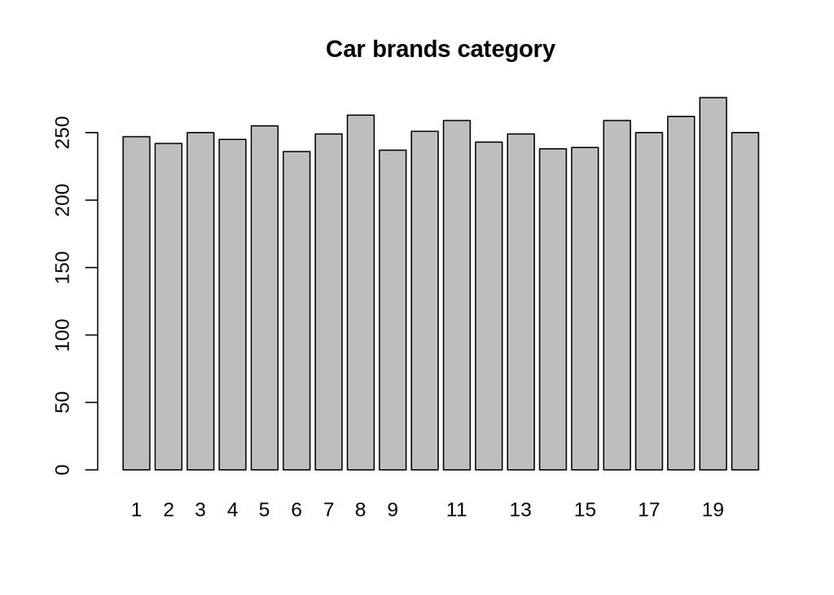

```r
barplot(table(dfIncomp$car), main = "Car brands category")
```

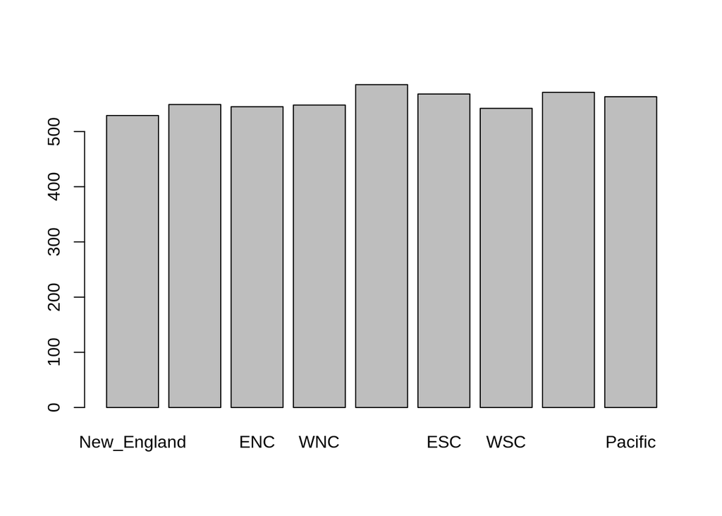

```r
barplot(table(dfIncomp$zipcode))
```

*We can see that distributions here are unsual, just as on the Complete dataset, but they are similar to each other. Due to this reason though, we can predict (classify) values on the new dataset.*

# **Normalizing Incomplete dataset**

```r
dfIncomp$salary <- (dfIncomp$salary - mean(dfIncomp$salary)) / sd(dfIncomp$salary)
dfIncomp$age <- (dfIncomp$age - mean(dfIncomp$age)) / sd(dfIncomp$age)
dfIncomp$credit <- (dfIncomp$credit - mean(dfIncomp$credit)) / sd(dfIncomp$credit)
head(dfIncomp)
```

|  | salary | age | elevel | car | zipcode | credit | brand |
| --- | --- | --- | --- | --- | --- | --- | --- |
| 1 | 0.6589812 | 0.23385609 | 4_Year_Degree_College | 15 | South_Atlantic | 0.7211372 | Acer |
| 2 | 1.4620670 | -0.33229917 | Master_PHD | 20 | Mountain | 0.9972925 | Acer |
| 3 | 0.8877976 | -0.04922154 | Some_College | 1 | WNC | -0.8737810 | Acer |
| 4 | -1.7322455 | 0.34708715 | Less_Than_High_School | 9 | Mid_Atlantic | -1.0272794 | Acer |
| 5 | 0.2218633 | 0.51693373 | High_School | 15 | Mid_Atlantic | 1.4336485 | Acer |
| 6 | -1.1677179 | 1.19632005 | Some_College | 7 | ENC | -0.2239221 | Acer |

# **Classifying Incomplete dataset**

```r
knnPredict <- predict(knnFit, newdata = dfIncomp)
summary(knnPredict)
```

```
## Acer Sony
## 1897 3103
```

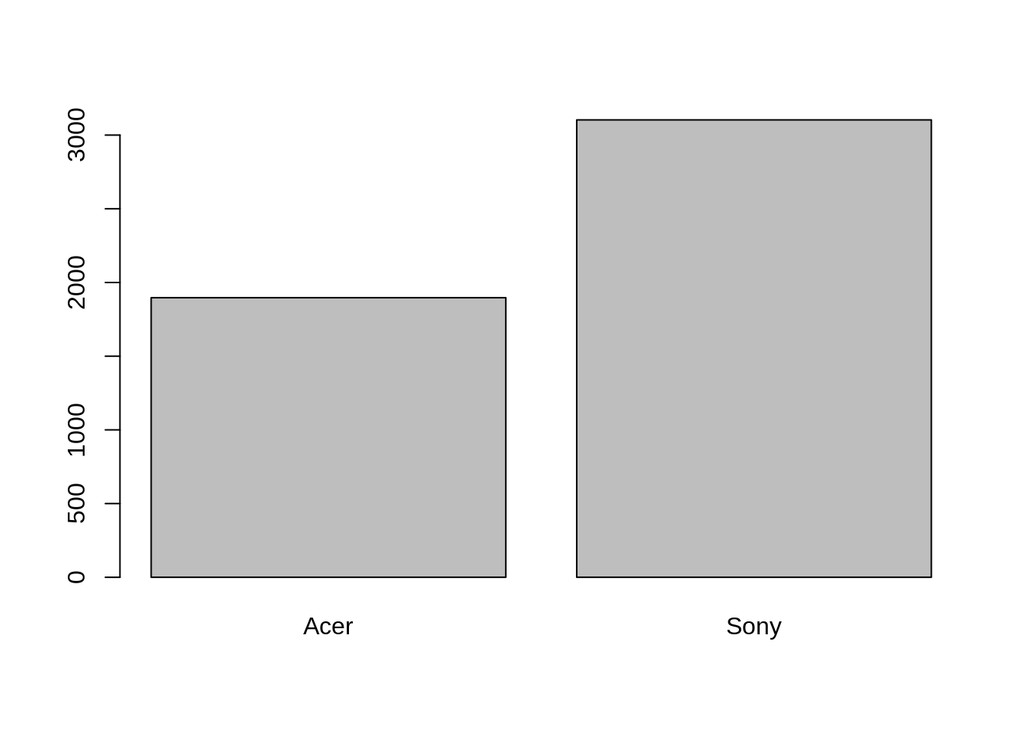

```r
plot(knnPredict)
```

*We can see the total amount of predictions made for each brand.*

# **Taking a look at Incomplete data with predicted values**

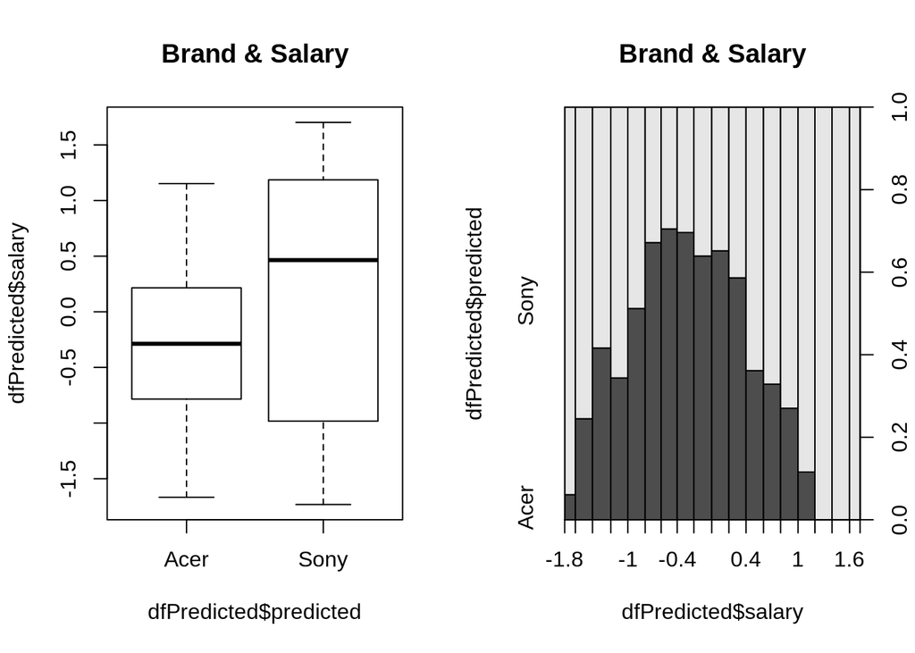

```r
dfPredicted = as.data.frame(dfIncomp)
dfPredicted["predicted"] <- knnPredict
dfPredicted = dfPredicted[,-7]

par(mfrow = c(1,2))
plot(dfPredicted$salary~dfPredicted$predicted, main = "Brand & Salary")
plot(dfPredicted$predicted~dfPredicted$salary, main = "Brand & Salary")
```

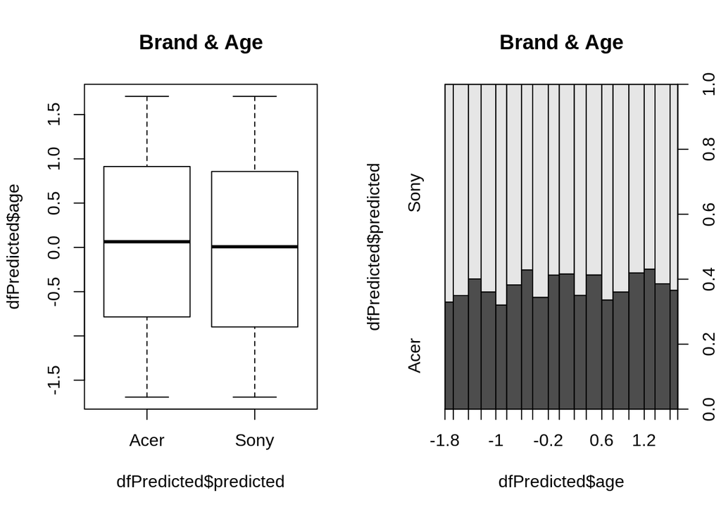

```r
par(mfrow = c(1,2))
plot(dfPredicted$age~dfPredicted$predicted, main = "Brand & Age")
plot(dfPredicted$predicted~dfPredicted$age, main = "Brand & Age")
```

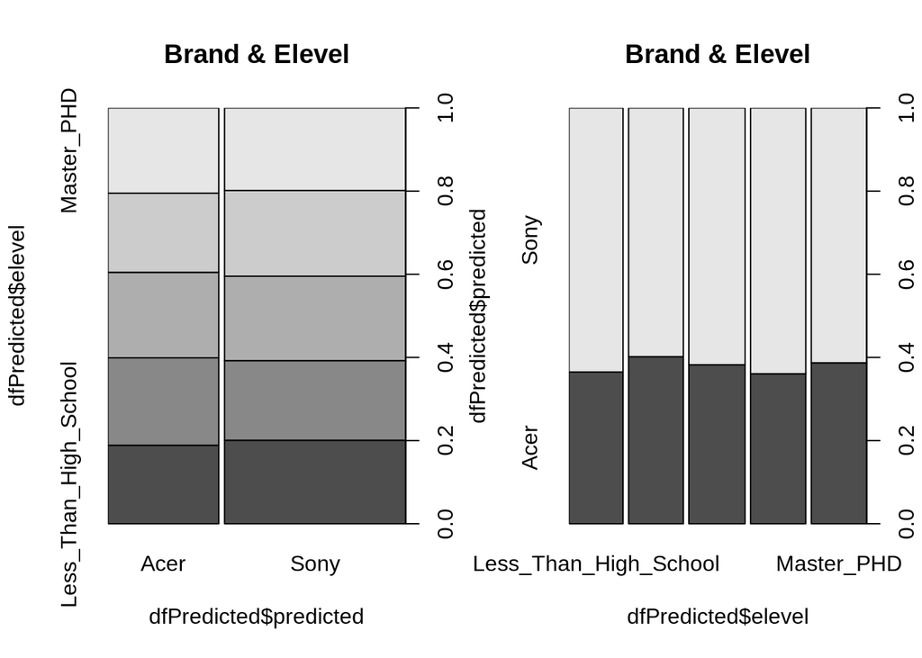

```r
par(mfrow = c(1,2))
plot(dfPredicted$elevel~dfPredicted$predicted, main = "Brand & Elevel")
plot(dfPredicted$predicted~dfPredicted$elevel, main = "Brand & Elevel")
```